# R Notebook

# Start timer

```r
ptm0 <- proc.time()
```

# Load libraries

```r
library(tidyverse)
library(dada2)
pass <- function(x){x}
set.seed(33100)
```

```r
packageVersion("dada2")
```

```
[1] ‘1.20.0’
```

To download the data, you should run the script `PullFastqFromSRA.sh` To download the silva daa run PullSilvaData.sh

```bash
#sh Scripts/PullFastqFromSRA.sh
```

```bash
#sh Scripts/PullSilvaData.sh
```

Data from SRA have serial numbers that are different from the file names to which I am accustomed.

Pull in metadata

```r
SRA_Data <- read_csv("StartingData/SraRunTable.csv")
```

Make some tables that are useful for data processing

```r
keyA1 <- SRA_Data %>% select(JacobName = `Library Name`, SRAName = Run) %>%
  separate(JacobName, into = c(NA, "Project", "Strain", "Treatment", "Group", "Run"), sep = "_", remove = FALSE)
keyA2 <- keyA1 %>%
  expand_grid(ReadDir = c(1,2)) %>%
  mutate(JacobName2 = paste0(JacobName, "_R", ReadDir),
         SRAName2 = paste0(SRAName, "_", ReadDir),
         JacobFile = paste0(JacobName2, ".fastq.gz"),
         SRAFile = paste0(SRAName2, ".fastq.gz")
         )
keyA2
```

| JacobName | Project | Strain | Treatment | Group | Run | SRAName | ReadDir | JacobName2 | SRAName2 | JacobFile | SRAFile |
| --- | --- | --- | --- | --- | --- | --- | --- | --- | --- | --- | --- |
| HPLOH_Crash_Wild_Starve_B_Crash4 | Crash | Wild | Starve | B | Crash4 | SRR15066673 | 1 | HPLOH_Crash_Wild_Starve_B_Crash4_R1 | SRR15066673_1 | HPLOH_Crash_Wild_Starve_B_Crash4_R1.fastq.gz | SRR15066673_1.fastq.gz |
| HPLOH_Crash_Wild_Starve_B_Crash4 | Crash | Wild | Starve | B | Crash4 | SRR15066673 | 2 | HPLOH_Crash_Wild_Starve_B_Crash4_R2 | SRR15066673_2 | HPLOH_Crash_Wild_Starve_B_Crash4_R2.fastq.gz | SRR15066673_2.fastq.gz |
| HPLOH_NoCrash_NA_Larvac__NoCrash | NoCrash | NA | Larvac |  | NoCrash | SRR15066681 | 1 | HPLOH_NoCrash_NA_Larvac__NoCrash_R1 | SRR15066681_1 | HPLOH_NoCrash_NA_Larvac__NoCrash_R1.fastq.gz | SRR15066681_1.fastq.gz |
| HPLOH_NoCrash_NA_Larvac__NoCrash | NoCrash | NA | Larvac |  | NoCrash | SRR15066681 | 2 | HPLOH_NoCrash_NA_Larvac__NoCrash_R2 | SRR15066681_2 | HPLOH_NoCrash_NA_Larvac__NoCrash_R2.fastq.gz | SRR15066681_2.fastq.gz |
| HPLOH_Crash_Wild_Pre_A_Crash4 | Crash | Wild | Pre | A | Crash4 | SRR15066682 | 1 | HPLOH_Crash_Wild_Pre_A_Crash4_R1 | SRR15066682_1 | HPLOH_Crash_Wild_Pre_A_Crash4_R1.fastq.gz | SRR15066682_1.fastq.gz |
| HPLOH_Crash_Wild_Pre_A_Crash4 | Crash | Wild | Pre | A | Crash4 | SRR15066682 | 2 | HPLOH_Crash_Wild_Pre_A_Crash4_R2 | SRR15066682_2 | HPLOH_Crash_Wild_Pre_A_Crash4_R2.fastq.gz | SRR15066682_2.fastq.gz |
| HPLOH_NoCrash_Aqua_Starve_C_NoCrash | NoCrash | Aqua | Starve | C | NoCrash | SRR15066683 | 1 | HPLOH_NoCrash_Aqua_Starve_C_NoCrash_R1 | SRR15066683_1 | HPLOH_NoCrash_Aqua_Starve_C_NoCrash_R1.fastq.gz | SRR15066683_1.fastq.gz |
| HPLOH_NoCrash_Aqua_Starve_C_NoCrash | NoCrash | Aqua | Starve | C | NoCrash | SRR15066683 | 2 | HPLOH_NoCrash_Aqua_Starve_C_NoCrash_R2 | SRR15066683_2 | HPLOH_NoCrash_Aqua_Starve_C_NoCrash_R2.fastq.gz | SRR15066683_2.fastq.gz |
| HPLOH_NoCrash_Aqua_Starve_A_NoCrash | NoCrash | Aqua | Starve | A | NoCrash | SRR15066685 | 1 | HPLOH_NoCrash_Aqua_Starve_A_NoCrash_R1 | SRR15066685_1 | HPLOH_NoCrash_Aqua_Starve_A_NoCrash_R1.fastq.gz | SRR15066685_1.fastq.gz |
| HPLOH_NoCrash_Aqua_Starve_A_NoCrash | NoCrash | Aqua | Starve | A | NoCrash | SRR15066685 | 2 | HPLOH_NoCrash_Aqua_Starve_A_NoCrash_R2 | SRR15066685_2 | HPLOH_NoCrash_Aqua_Starve_A_NoCrash_R2.fastq.gz | SRR15066685_2.fastq.gz |

[output cut: 60 more lines]

For the phyloseq objectdada

```r
keyA1 %>%
  select(Sample = JacobName, Project:Run) %>%
  write_csv("UsefulData/sample_data.csv")
```

Add paths so I can tell various steps where files go and what to call them

```r
keyA3 <- keyA2 %>%
  mutate(TrimmedPath = str_c("Trimmed/", JacobName2, "_trimmed.fastq.gz")) %>%
  mutate(FilteredPath = str_c("Filtered/", JacobName2, "_filtered.fastq.gz")) %>%
  mutate(DerepPath = str_c("Derep/", JacobName2, "_derep.fastq.gz"))
```

For primer trimming, I need a file of sample names

```r
write_lines(keyA2$JacobName, "IntermediateData/samples.txt")
```

Rename all of the files

First clear the renamed directory, if it contains any files

```r
do.call(file.remove, list(list.files("Renamed", full.names = "TRUE")))
```

```
 [1] TRUE TRUE TRUE TRUE TRUE TRUE TRUE TRUE TRUE TRUE TRUE TRUE TRUE TRUE TRUE
[16] TRUE TRUE TRUE TRUE TRUE TRUE TRUE TRUE TRUE TRUE TRUE TRUE TRUE TRUE TRUE
[31] TRUE TRUE TRUE TRUE TRUE TRUE TRUE TRUE TRUE TRUE TRUE TRUE TRUE TRUE TRUE
[46] TRUE TRUE TRUE TRUE TRUE TRUE TRUE TRUE TRUE TRUE TRUE TRUE TRUE TRUE TRUE
[61] TRUE TRUE TRUE TRUE TRUE TRUE TRUE TRUE TRUE TRUE
```

Then copy the files to the renamed directory with their new names

```r
didCopy <- file.copy(paste0("SRA_Readfiles/", keyA2$SRAFile),paste0("Renamed/", keyA2$JacobFile))
didCopy
```

```
 [1] TRUE TRUE TRUE TRUE TRUE TRUE TRUE TRUE TRUE TRUE TRUE TRUE TRUE TRUE TRUE
[16] TRUE TRUE TRUE TRUE TRUE TRUE TRUE TRUE TRUE TRUE TRUE TRUE TRUE TRUE TRUE
[31] TRUE TRUE TRUE TRUE TRUE TRUE TRUE TRUE TRUE TRUE TRUE TRUE TRUE TRUE TRUE
[46] TRUE TRUE TRUE TRUE TRUE TRUE TRUE TRUE TRUE TRUE TRUE TRUE TRUE TRUE TRUE
[61] TRUE TRUE TRUE TRUE TRUE TRUE TRUE TRUE TRUE TRUE
```

This should be a vector of TRUEs. If it isn’t its likely that not all of the SRA files downloaded.

# Run Cutadapt

I need to have cutadapt loaded before I run rstudio on my machine for this to work

```bash
for sample in $(cat IntermediateData/samples.txt)
do

    echo "On sample: $sample"

    cutadapt -a ^GTGYCAGCMGCCGCGGTAA...AAACTYAAAKRAATTGRCGG \
-A ^CCGYCAATTYMTTTRAGTTT...TTACCGCGGCKGCTGRCAC \
 -m 200 --discard-untrimmed \
    -o Trimmed/${sample}_R1_trimmed.fastq.gz -p Trimmed/${sample}_R2_trimmed.fastq.gz \
    Renamed/${sample}_R1.fastq.gz Renamed/${sample}_R2.fastq.gz \
    >> IntermediateData/cutadapt_primer_trimming_stats.txt 2>&1
done
```

```
On sample: HPLOH_Crash_Wild_Starve_B_Crash4
On sample: HPLOH_Crash_Wild_Starve_B_Crash4
On sample: HPLOH_NoCrash_NA_Larvac__NoCrash
On sample: HPLOH_NoCrash_NA_Larvac__NoCrash
On sample: HPLOH_Crash_Wild_Pre_A_Crash4
On sample: HPLOH_Crash_Wild_Pre_A_Crash4
On sample: HPLOH_NoCrash_Aqua_Starve_C_NoCrash
On sample: HPLOH_NoCrash_Aqua_Starve_C_NoCrash
On sample: HPLOH_NoCrash_Aqua_Starve_A_NoCrash
On sample: HPLOH_NoCrash_Aqua_Starve_A_NoCrash
On sample: HPLOH_NoCrash_Aqua_Fed_A_NoCrash
On sample: HPLOH_NoCrash_Aqua_Fed_A_NoCrash
On sample: HPLOH_NoCrash_Wild_Starve_A_NoCrash
On sample: HPLOH_NoCrash_Wild_Starve_A_NoCrash
On sample: HPLOH_NoCrash_Wild_Fed_C_NoCrash
On sample: HPLOH_NoCrash_Wild_Fed_C_NoCrash
On sample: HPLOH_NoCrash_Wild_Fed_B_NoCrash
On sample: HPLOH_NoCrash_Wild_Fed_B_NoCrash
On sample: HPLOH_Crash_NEH_Starve_B_Crash4
On sample: HPLOH_Crash_NEH_Starve_B_Crash4
On sample: HPLOH_Crash_NEH_Pre_C_Crash4
On sample: HPLOH_Crash_NEH_Pre_C_Crash4
On sample: HPLOH_Crash_NEH_Pre_A_Crash4
On sample: HPLOH_Crash_NEH_Pre_A_Crash4
On sample: HPLOH_Crash_Wild_Pre_C_Crash4
On sample: HPLOH_Crash_Wild_Pre_C_Crash4
On sample: HPLOH_Crash_Wild_Pre_B_Crash4
On sample: HPLOH_Crash_Wild_Pre_B_Crash4
On sample: HPLOH_Blank_NA_NA_3MAR2020_Crash4
On sample: HPLOH_Blank_NA_NA_3MAR2020_Crash4
On sample: HPLOH_Blank_NA_NA_26FEB2020_Crash4
On sample: HPLOH_Blank_NA_NA_26FEB2020_Crash4
On sample: HPLOH_Crash_NEH_Fed_A_Crash4
On sample: HPLOH_Crash_NEH_Fed_A_Crash4
On sample: HPLOH_Mock_Staggered_NA__NoCrash
On sample: HPLOH_Mock_Staggered_NA__NoCrash
On sample: HPLOH_NoCrash_Aqua_Starve_B_NoCrash
On sample: HPLOH_NoCrash_Aqua_Starve_B_NoCrash
On sample: HPLOH_Crash_Wild_Fed_C_Crash4
On sample: HPLOH_Crash_Wild_Fed_C_Crash4
```

[output cut: 15 more lines]

```
On sample: HPLOH_NoCrash_Wild_Fed_A_Crash4
On sample: HPLOH_NoCrash_Wild_Starve_C_NoCrash
On sample: HPLOH_NoCrash_Wild_Starve_C_NoCrash
On sample: HPLOH_NoCrash_Wild_Starve_B_NoCrash
On sample: HPLOH_NoCrash_Wild_Starve_B_NoCrash
On sample: HPLOH_Crash_Wild_Starve_C_Crash4
On sample: HPLOH_Crash_Wild_Starve_C_Crash4
On sample: HPLOH_NoCrash_Wild_Starve_A_Crash4
On sample: HPLOH_NoCrash_Wild_Starve_A_Crash4
On sample: HPLOH_Crash_NEH_Starve_C_Crash4
On sample: HPLOH_Crash_NEH_Starve_C_Crash4
On sample: HPLOH_Mock_Even_NA__NoCrash
On sample: HPLOH_Mock_Even_NA__NoCrash
On sample: HPLOH_Crash_Wild_Fed_A_Crash4
On sample: HPLOH_Crash_Wild_Fed_A_Crash4
```

## Plot Errors

```r
toPlot <- keyA3 %>%
  #filter(Strain == "Wild", Treatment == "Fed", Group == "A")
  filter(Strain == "Wild", Treatment == "Fed", Group %in% c("A", "B"))
toPlotFwd <- toPlot %>%
  filter(ReadDir == 1) %>%
  pull(TrimmedPath)
toPlotRev <- toPlot %>%
  filter(ReadDir == 2) %>%
  pull(TrimmedPath)
```

Forward reads

```
`guides(<scale> = FALSE)` is deprecated. Please use `guides(<scale> = "none")` instead.
```

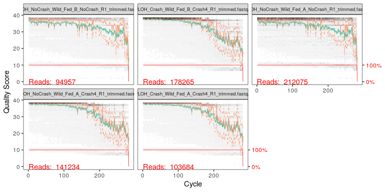

```r
plotQualityProfile(toPlotFwd) +theme(strip.text = element_text(size = 7))
```

```
`guides(<scale> = FALSE)` is deprecated. Please use `guides(<scale> = "none")` instead.
```

[figure not shown]

```r
plotQualityProfile(toPlotFwd) +theme(strip.text = element_text(size = 7))
```

# Filtering files

We can filter everything in one batch, but we have to do dada2 and learn errors on two batches, one for each run.

First, I need to get the names of the forward and reverse read files

```r
files_to_filter <- keyA3 %>%
  select(Project:ReadDir, TrimmedPath, FilteredPath) %>%
  #filter(Strain == "Wild", Treatment == "Fed", Group == "A") %>% # Debugging
  pivot_longer(cols = contains("Path"), names_to = "PathType", values_to = "Path") %>%
  mutate(cname = str_c(PathType, "_R", ReadDir)) %>%
  select(-PathType, -ReadDir) %>%
  pivot_wider(names_from = cname, values_from = "Path") %>%
  pass
```

Do the filtering

```r
pt0 <- proc.time()
filtered <- filterAndTrim(fwd  = files_to_filter$TrimmedPath_R1,
                          filt = files_to_filter$FilteredPath_R1,
                          rev  = files_to_filter$TrimmedPath_R2,
                          filt.rev  = files_to_filter$FilteredPath_R2,
                          maxEE=c(3,5),
                          rm.phix=TRUE, minLen=175, truncLen=c(230,220))
pt1 <- proc.time()
pt1 - pt0
```

```
   user  system elapsed
585.118  40.464 625.437
```

```r
write_csv(keyA3, "IntermediateData/keyA3.csv")
write_csv(files_to_filter , "IntermediateData/files_for_learning_errors.csv")
```

Then run LearningErrors.R

```bash
Rscript Scripts/TestScript.R
```

```
[1] "/home/jacob/Projects/HPLOH_Crash"
```

```bash
Rscript Scripts/LearningErrors.R
```

```
[1] ‘1.20.0’
```

```
106405820 total bases in 462634 reads from 7 samples will be used for learning the error rates.
101299130 total bases in 440431 reads from 4 samples will be used for learning the error rates.
105754660 total bases in 480703 reads from 9 samples will be used for learning the error rates.
107275300 total bases in 487615 reads from 4 samples will be used for learning the error rates.
```

```bash
Rscript Scripts/DerepAll.R
```

```
[1] ‘1.20.0’
```

```
Dereplicating sequence entries in Fastq file: Filtered/HPLOH_Crash_Wild_Starve_B_Crash4_R1_filtered.fastq.gz
Encountered 9790 unique sequences from 58910 total sequences read.
Dereplicating sequence entries in Fastq file: Filtered/HPLOH_NoCrash_NA_Larvac__NoCrash_R1_filtered.fastq.gz
Encountered 53346 unique sequences from 165484 total sequences read.
Dereplicating sequence entries in Fastq file: Filtered/HPLOH_Crash_Wild_Pre_A_Crash4_R1_filtered.fastq.gz
Encountered 14281 unique sequences from 67566 total sequences read.
Dereplicating sequence entries in Fastq file: Filtered/HPLOH_NoCrash_Aqua_Starve_C_NoCrash_R1_filtered.fastq.gz
Encountered 17990 unique sequences from 70324 total sequences read.
Dereplicating sequence entries in Fastq file: Filtered/HPLOH_NoCrash_Aqua_Starve_A_NoCrash_R1_filtered.fastq.gz
Encountered 48761 unique sequences from 138031 total sequences read.
Dereplicating sequence entries in Fastq file: Filtered/HPLOH_NoCrash_Aqua_Fed_A_NoCrash_R1_filtered.fastq.gz
Encountered 32456 unique sequences from 109093 total sequences read.
Dereplicating sequence entries in Fastq file: Filtered/HPLOH_NoCrash_Wild_Starve_A_NoCrash_R1_filtered.fastq.gz
Encountered 19441 unique sequences from 83414 total sequences read.
Dereplicating sequence entries in Fastq file: Filtered/HPLOH_NoCrash_Wild_Fed_C_NoCrash_R1_filtered.fastq.gz
Encountered 26643 unique sequences from 122983 total sequences read.
Dereplicating sequence entries in Fastq file: Filtered/HPLOH_NoCrash_Wild_Fed_B_NoCrash_R1_filtered.fastq.gz
Encountered 13798 unique sequences from 53997 total sequences read.
Dereplicating sequence entries in Fastq file: Filtered/HPLOH_Crash_NEH_Starve_B_Crash4_R1_filtered.fastq.gz
Encountered 14541 unique sequences from 91644 total sequences read.
Dereplicating sequence entries in Fastq file: Filtered/HPLOH_Crash_NEH_Pre_C_Crash4_R1_filtered.fastq.gz
Encountered 9082 unique sequences from 56554 total sequences read.
Dereplicating sequence entries in Fastq file: Filtered/HPLOH_Crash_NEH_Pre_A_Crash4_R1_filtered.fastq.gz
Encountered 5540 unique sequences from 24307 total sequences read.
Dereplicating sequence entries in Fastq file: Filtered/HPLOH_Crash_Wild_Pre_C_Crash4_R1_filtered.fastq.gz
Encountered 3208 unique sequences from 13902 total sequences read.
Dereplicating sequence entries in Fastq file: Filtered/HPLOH_Crash_Wild_Pre_B_Crash4_R1_filtered.fastq.gz
Encountered 13894 unique sequences from 93149 total sequences read.
Dereplicating sequence entries in Fastq file: Filtered/HPLOH_Blank_NA_NA_3MAR2020_Crash4_R1_filtered.fastq.gz
Encountered 2802 unique sequences from 11169 total sequences read.
Dereplicating sequence entries in Fastq file: Filtered/HPLOH_Blank_NA_NA_26FEB2020_Crash4_R1_filtered.fastq.gz
Encountered 5661 unique sequences from 20111 total sequences read.
Dereplicating sequence entries in Fastq file: Filtered/HPLOH_Crash_NEH_Fed_A_Crash4_R1_filtered.fastq.gz
Encountered 12740 unique sequences from 44784 total sequences read.
Dereplicating sequence entries in Fastq file: Filtered/HPLOH_Mock_Staggered_NA__NoCrash_R1_filtered.fastq.gz
Encountered 25778 unique sequences from 98874 total sequences read.
Dereplicating sequence entries in Fastq file: Filtered/HPLOH_NoCrash_Aqua_Starve_B_NoCrash_R1_filtered.fastq.gz
Encountered 13305 unique sequences from 49620 total sequences read.
Dereplicating sequence entries in Fastq file: Filtered/HPLOH_Crash_Wild_Fed_C_Crash4_R1_filtered.fastq.gz
Encountered 11832 unique sequences from 35050 total sequences read.
```

[output cut: 85 more lines]

```
Encountered 66930 unique sequences from 96529 total sequences read.
Dereplicating sequence entries in Fastq file: Filtered/HPLOH_NoCrash_Wild_Starve_C_NoCrash_R2_filtered.fastq.gz
Encountered 42467 unique sequences from 121976 total sequences read.
Dereplicating sequence entries in Fastq file: Filtered/HPLOH_NoCrash_Wild_Starve_B_NoCrash_R2_filtered.fastq.gz
Encountered 56996 unique sequences from 151582 total sequences read.
Dereplicating sequence entries in Fastq file: Filtered/HPLOH_Crash_Wild_Starve_C_Crash4_R2_filtered.fastq.gz
Encountered 36294 unique sequences from 54259 total sequences read.
Dereplicating sequence entries in Fastq file: Filtered/HPLOH_NoCrash_Wild_Starve_A_Crash4_R2_filtered.fastq.gz
Encountered 43908 unique sequences from 57023 total sequences read.
Dereplicating sequence entries in Fastq file: Filtered/HPLOH_Crash_NEH_Starve_C_Crash4_R2_filtered.fastq.gz
Encountered 29668 unique sequences from 39667 total sequences read.
Dereplicating sequence entries in Fastq file: Filtered/HPLOH_Mock_Even_NA__NoCrash_R2_filtered.fastq.gz
Encountered 65517 unique sequences from 129929 total sequences read.
Dereplicating sequence entries in Fastq file: Filtered/HPLOH_Crash_Wild_Fed_A_Crash4_R2_filtered.fastq.gz
Encountered 53183 unique sequences from 67914 total sequences read.
```

```bash
Rscript Scripts/DadaAll.R
```

```
Sample 1 - 58910 reads in 9790 unique sequences.
Sample 2 - 67566 reads in 14281 unique sequences.
Sample 3 - 91644 reads in 14541 unique sequences.
Sample 4 - 56554 reads in 9082 unique sequences.
Sample 5 - 24307 reads in 5540 unique sequences.
Sample 6 - 13902 reads in 3208 unique sequences.
Sample 7 - 93149 reads in 13894 unique sequences.
Sample 8 - 11169 reads in 2802 unique sequences.
Sample 9 - 20111 reads in 5661 unique sequences.
Sample 10 - 44784 reads in 12740 unique sequences.
Sample 11 - 35050 reads in 11832 unique sequences.
Sample 12 - 9057 reads in 4080 unique sequences.
Sample 13 - 122177 reads in 32395 unique sequences.
Sample 14 - 44902 reads in 7792 unique sequences.
Sample 15 - 43248 reads in 7721 unique sequences.
Sample 16 - 96529 reads in 21396 unique sequences.
Sample 17 - 54259 reads in 13000 unique sequences.
Sample 18 - 57023 reads in 16452 unique sequences.
Sample 19 - 39667 reads in 11390 unique sequences.
Sample 20 - 67914 reads in 20422 unique sequences.

   selfConsist step 2Sample 1 - 165484 reads in 53346 unique sequences.
Sample 2 - 70324 reads in 17990 unique sequences.
Sample 3 - 138031 reads in 48761 unique sequences.
Sample 4 - 109093 reads in 32456 unique sequences.
Sample 5 - 83414 reads in 19441 unique sequences.
Sample 6 - 122983 reads in 26643 unique sequences.
Sample 7 - 53997 reads in 13798 unique sequences.
Sample 8 - 98874 reads in 25778 unique sequences.
Sample 9 - 49620 reads in 13305 unique sequences.
Sample 10 - 327187 reads in 83586 unique sequences.
Sample 11 - 124931 reads in 49936 unique sequences.
Sample 12 - 115734 reads in 24637 unique sequences.
Sample 13 - 121976 reads in 26768 unique sequences.
Sample 14 - 151582 reads in 32517 unique sequences.
Sample 15 - 129929 reads in 40797 unique sequences.

   selfConsist step 2Sample 1 - 58910 reads in 36232 unique sequences.
Sample 2 - 67566 reads in 41505 unique sequences.
Sample 3 - 91644 reads in 55736 unique sequences.
```

[output cut: 20 more lines]

```
Sample 3 - 138031 reads in 70855 unique sequences.
Sample 4 - 109093 reads in 52327 unique sequences.
Sample 5 - 83414 reads in 29909 unique sequences.
Sample 6 - 122983 reads in 53285 unique sequences.
Sample 7 - 53997 reads in 22602 unique sequences.
Sample 8 - 98874 reads in 44163 unique sequences.
Sample 9 - 49620 reads in 22433 unique sequences.
Sample 10 - 327187 reads in 120510 unique sequences.
Sample 11 - 124931 reads in 71769 unique sequences.
Sample 12 - 115734 reads in 50666 unique sequences.
Sample 13 - 121976 reads in 42467 unique sequences.
Sample 14 - 151582 reads in 56996 unique sequences.
Sample 15 - 129929 reads in 65517 unique sequences.

   selfConsist step 2
```

```bash
Rscript Scripts/MergeAndTableify.R
```

[output not shown]

```bash
Rscript Scripts/GetTaxa.R
```

```
[1] 0.963776
```

```bash
Rscript Scripts/MakePhyloseqIngredients.R
```

```bash
Rscript Scripts/MakePhyloseqObject.R
```

# Stop timer

```r
ptm1 <- proc.time()
ptm1 - ptm0
```

```
     user    system   elapsed
26366.446   478.895 11225.596
```